# Liquor Sales VS DUI Accidents

Gaurav Madarkal

8/15/2021

## Introduction

This is a data analytics project written in R language, the goal of this project is to gather Liquor Sales data and the DUI(Driving under Infuence) Accidents data, and try to find a correlation between the two, do the states which have higher amount of alcohol sales have a higher rate of DUI reports? or are the two completely unrelated?. We can achieve by understanding the data we can find. The requirements for this project would be to find a dataset which gives us both sales data as well as the DUI reports data. But, unfortunately we are not that lucky, so let start searching the internet to find relevant info so that we can create such a dataset.  
let choose a timeline, 2014 - 2018, its the perfect timeline because the millenials would have turned 18 or above. Firstly, lets try to gather the liquor sales data, we need to find a dataset that gives us the liquor consumption data.  
**ICPSR** - has an open dataset available which provides a per capita alcohol consumption state wise, which is not 100% what we want, but its a step forward. Now we have per capita gallon based data, now we need to find the state wise population for the respective year so that we can find the total gallons consumed by a state in a year. For this lets visit the census website which gives us this info  
After computation we will have the total alcohol consumed by a state in a year.  
Finally, we need to gather the DUI accident reports. The **NHTSA** has datasets for accidents reported for each year.  
**Great, we now have all the data we need to get started.**

## Installing required dependencies

```r
library(dplyr)
```

```r
library(usmap)
library(ggplot2)
```

## Loading Data - Accident reports - Year wise

```r
# INDIVIDUAL YEAR DATA

accidents_2014 <- read.csv('./Datasets/accident_2014.csv')[ ,c('STATE', 'YEAR', 'DRUNK_DR')]
accidents_2015 <- read.csv('./Datasets/accident_2015.csv')[ ,c('STATE', 'YEAR', 'DRUNK_DR')]
accidents_2016 <- read.csv('./Datasets/accident_2016.csv')[ ,c('STATE', 'YEAR', 'DRUNK_DR')]
accidents_2017 <- read.csv('./Datasets/accident_2017.csv')[ ,c('STATE', 'YEAR', 'DRUNK_DR')]
accidents_2018 <- read.csv('./Datasets/accident_2018.csv')[ ,c('STATE', 'YEAR', 'DRUNK_DR')]
#accidents_2019 <- read.csv('./Datasets/accident_2019.csv')[ ,c('STATE', 'YEAR', 'DRUNK_DR')]

# STATE NUMBERS
state_numbers_data <- read.csv('./Datasets/state_names_numbers.csv')
```

## Loading Data - Census - Year wise

```r
# GET THE POPULATION DATA FROM YEAR 2015 TO 2019 SO THAT WE CAN CALCULATE THE GALLONS ON ALCOHOL CONSUMED/SOLD STATE WISE
population_state_year <- read.csv('./Datasets/population_statewise_2014-2018.csv', check.names = FALSE)[, c("Name", "2014", "2015", '2016', "2017", "2018")]

# GET THE ALCOHOL CONSUMED DATA, WHICH HAS ETHANOL CONSUMED PER CAPITA
liquor_sales_raw <- read.csv('./Datasets/apparent_per_capita_liquor_sales_1977_2018.csv')
```

## Filtering Data and cleaning it

```r
# COMBINE ALL REPORTS FROM EACH YEAR
accidents_all <- rbind(accidents_2014, accidents_2015, accidents_2016, accidents_2017, accidents_2018)

# FILTER ACCIDENTS WHICH ARE DRUNK DRIVE ONLY
dui_accidents_all <- subset(accidents_all, DRUNK_DR == 1)

# RETRIEVE THE STATENAMES BY JOINING WITH STATE NUMBERS
accidents_state_wise <- merge(dui_accidents_all, state_numbers_data, all.x = FALSE, all.y = FALSE)
accidents_state_wise$region <- tolower(accidents_state_wise$STATE_NAME)

# FILTER THE REQUIRED YEARS AND COLUMNS
liquor_sales_2014_2018 <- subset(liquor_sales_raw, year %in% c("2014", "2015", "2016", "2017", "2018"))[, c('state', 'year', 'ethanol_all_drinks_gallons_per_capita')]
```

## Calculating Overall Alcohol Sales per state

```r
# NORMALIZE THE STATE NAMES BY MAKING THEM UPPER CASE
liquor_sales_2014_2018$region <- tolower(liquor_sales_2014_2018$state)

# NORMALIZE THE STATE NAMES BY MAKING THEM UPPER CASE
population_state_year$region <- tolower(population_state_year$Name)

# DECLARE ALL THE STATE POPULATION AS 0 INITIALLY
liquor_sales_2014_2018[, "population"] = 0

# LOOP OVER THE INDIVIDUAL STATE POPULATION AND ADD THE VALUES TO ALCOHOL SALES DATA SET
# SINCE THE POPULATION DATASET IS IN A MATRIX FORMAT WE NEED TO LOOP OVER EACH ENTRY AND CANNOT AUTOMATICALLY JOIN
i <- 1
for (row in 1:nrow(population_state_year)) {
  if (i < nrow(liquor_sales_2014_2018)) {
      liquor_sales_2014_2018[i, "population"] = population_state_year[row, "2018"]
      liquor_sales_2014_2018[i + 1, "population"] = population_state_year[row, "2017"]
      liquor_sales_2014_2018[i + 2, "population"] = population_state_year[row, "2016"]
      liquor_sales_2014_2018[i + 3, "population"] = population_state_year[row, "2015"]
      liquor_sales_2014_2018[i + 4, "population"] = population_state_year[row, "2014"]
      i <- i + 5
  }
}
# REMOVE COMMAS AND CONVERT THE POPULATION VALUE TO A NUMERIC ONE
liquor_sales_2014_2018$population <-  as.numeric(gsub(",","",liquor_sales_2014_2018$population))

# MULIPLY THE POPULATION WITH THE PER CAPITA sales WHICH WILL GIVE US THE TOTAL GALLONS A STATE CONSUMED IN THAT YEAR
liquor_sales_2014_2018$total_gallons <- liquor_sales_2014_2018$ethanol_all_drinks_gallons_per_capita * liquor_sales_2014_2018$population
```

## Aggregating total DUI accidents for a year for a state

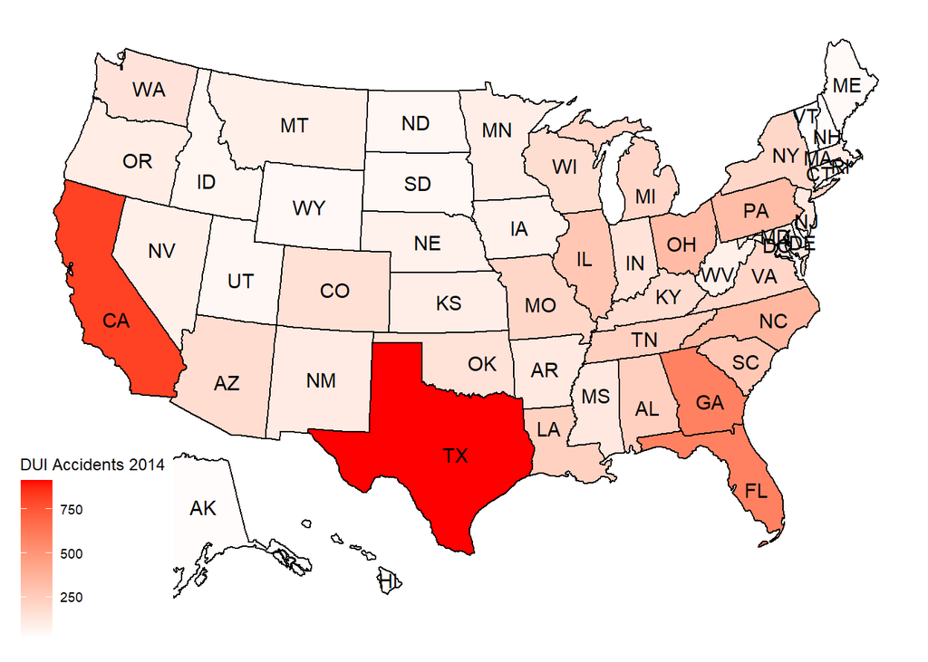

```r
accidents_year_vs_state <- setNames(aggregate(accidents_state_wise$DRUNK_DR, by=list(state=accidents_state_wise$STATE_NAME, year=accidents_state_wise$YEAR), FUN=sum), c("state", "year", "occurences"))
accidents_year_vs_state$fips = fips(accidents_year_vs_state$state)
map_data <- inner_join(us_map(), accidents_year_vs_state)
### ACCIDENTS USA HEATMAP FOR 2014 ###
plot_usmap(data = subset(map_data, year=='2014') %>% select(fips, occurences), values="occurences", labels = TRUE) +
    scale_fill_continuous(low = "white", high = "red", name = "DUI Accidents 2014", label = scales::comma)
```

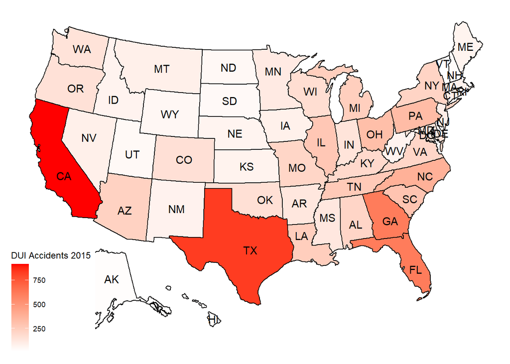

```r
ggsave('./Plots/dui_accidents_2014.png', last_plot())
### ACCIDENTS USA HEATMAP FOR 2015 ###
plot_usmap(data = subset(map_data, year=='2015') %>% select(fips, occurences), values="occurences", labels = TRUE) +
    scale_fill_continuous(low = "white", high = "red", name = "DUI Accidents 2015", label = scales::comma)
```

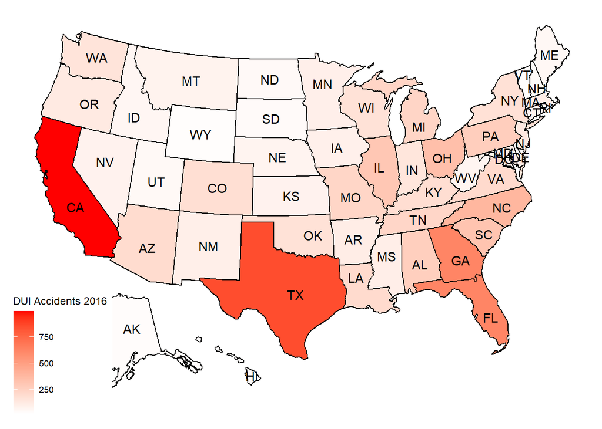

```r
ggsave('./Plots/dui_accidents_2015.png', last_plot())
### ACCIDENTS USA HEATMAP FOR 2016 ###
plot_usmap(data = subset(map_data, year=='2016') %>% select(fips, occurences), values="occurences", labels = TRUE) +
    scale_fill_continuous(low = "white", high = "red", name = "DUI Accidents 2016", label = scales::comma)
```

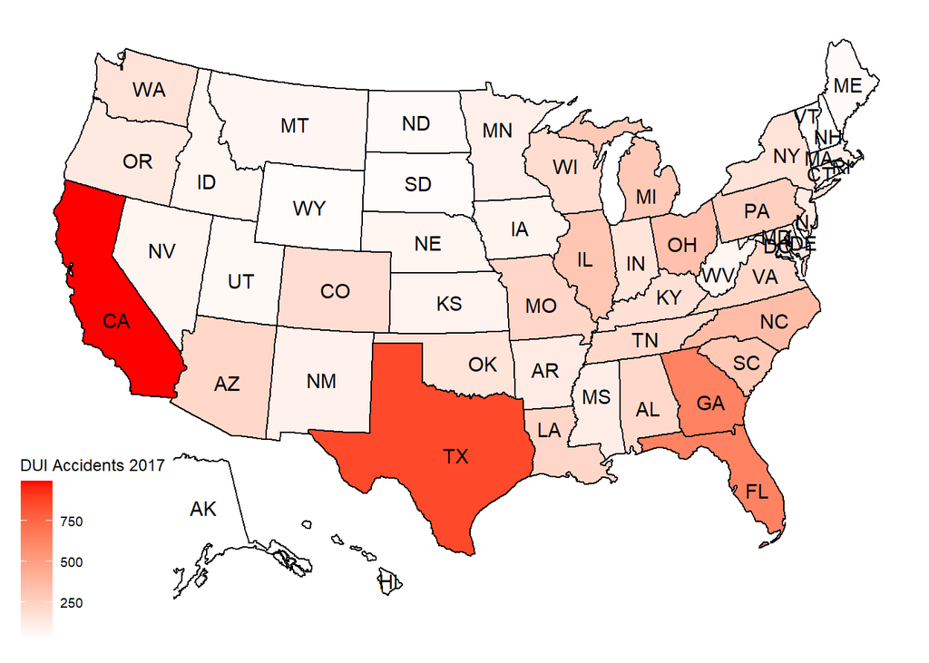

```r
ggsave('./Plots/dui_accidents_2016.png', last_plot())
### ACCIDENTS USA HEATMAP FOR 2017 ###
plot_usmap(data = subset(map_data, year=='2017') %>% select(fips, occurences), values="occurences", labels = TRUE) +
    scale_fill_continuous(low = "white", high = "red", name = "DUI Accidents 2017", label = scales::comma)
```

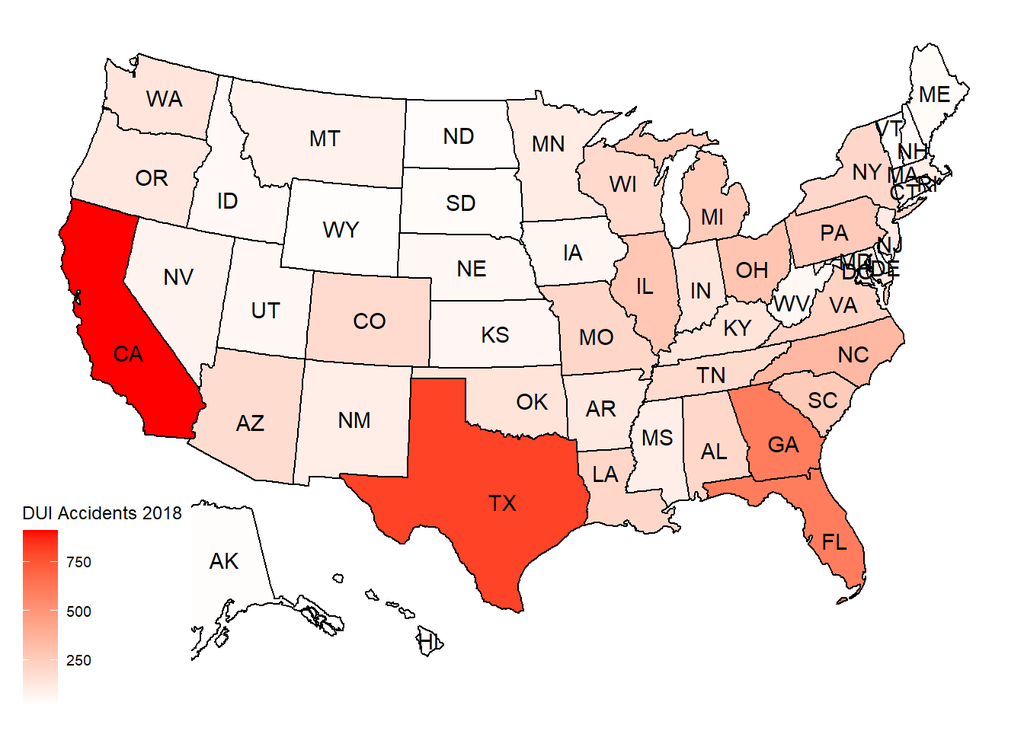

```r
ggsave('./Plots/dui_accidents_2017.png', last_plot())
### ACCIDENTS USA HEATMAP FOR 2018 ###
plot_usmap(data = subset(map_data, year=='2018') %>% select(fips, occurences), values="occurences", labels = TRUE) +
    scale_fill_continuous(low = "white", high = "red", name = "DUI Accidents 2018", label = scales::comma)
```

```r
ggsave('./Plots/dui_accidents_2018.png', last_plot())
```

## Plotting USA heat map to understand which states have higher and lower amount of alcohol sales

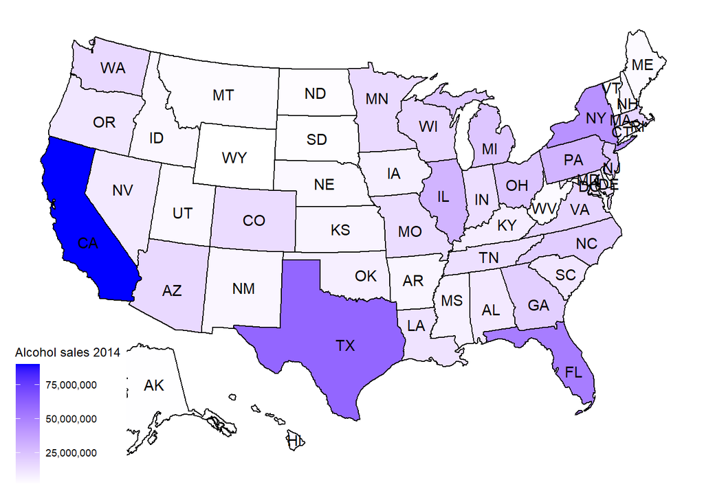

```r
liquor_sales_2014_2018$fips = fips(liquor_sales_2014_2018$state)
map_data <- inner_join(us_map(), liquor_sales_2014_2018)
### ALCOHOL sales FOR YEAR 2014 ###
plot_usmap(data = subset(map_data, year == "2014") %>% select(fips, total_gallons), values="total_gallons", labels = TRUE) +
    scale_fill_continuous(low = "white", high = "blue", name = "Alcohol sales 2014", label = scales::comma)
```

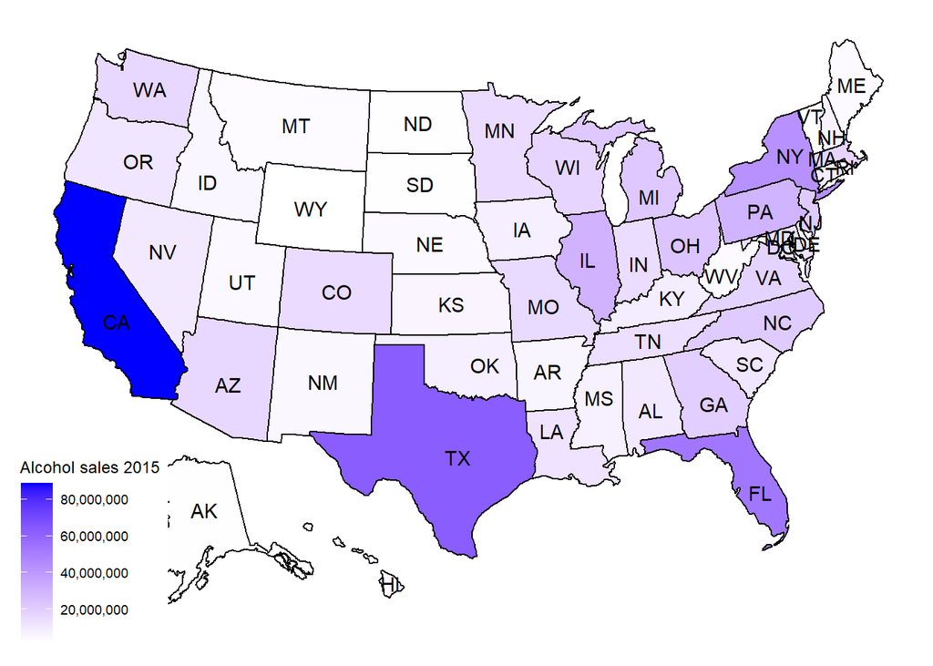

```r
ggsave('./Plots/liqour_sales_2014.png', last_plot())
### ALCOHOL sales FOR YEAR 2015 ###
plot_usmap(data = subset(map_data, year == "2015") %>% select(fips, total_gallons), values="total_gallons", labels = TRUE) +
    scale_fill_continuous(low = "white", high = "blue", name = "Alcohol sales 2015", label = scales::comma)
```

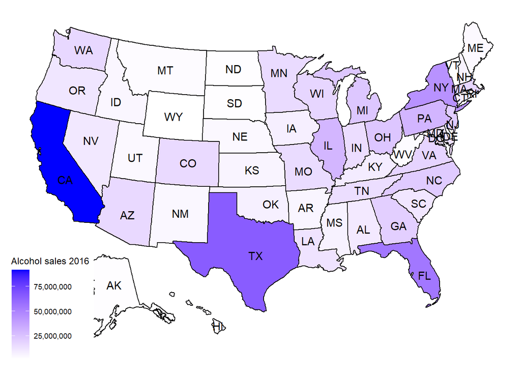

```r
ggsave('./Plots/liqour_sales_2015.png', last_plot())
### ALCOHOL sales FOR YEAR 2016 ###
plot_usmap(data = subset(map_data, year == "2016") %>% select(fips, total_gallons), values="total_gallons", labels = TRUE) +
    scale_fill_continuous(low = "white", high = "blue", name = "Alcohol sales 2016", label = scales::comma)
```

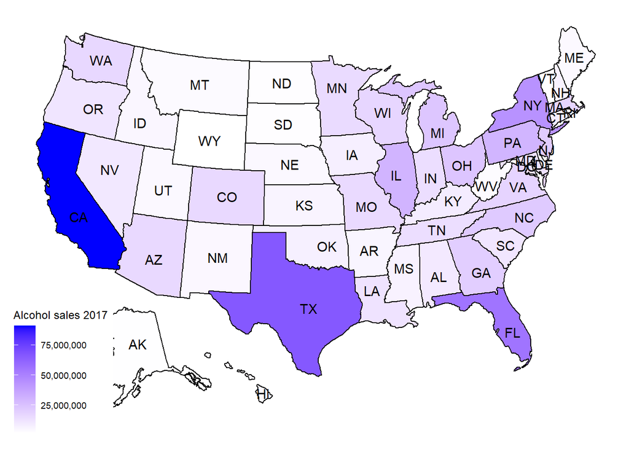

```r
ggsave('./Plots/liqour_sales_2016.png', last_plot())
### ALCOHOL sales FOR YEAR 2017 ###
plot_usmap(data = subset(map_data, year == "2017") %>% select(fips, total_gallons), values="total_gallons", labels = TRUE) +
    scale_fill_continuous(low = "white", high = "blue", name = "Alcohol sales 2017", label = scales::comma)
```

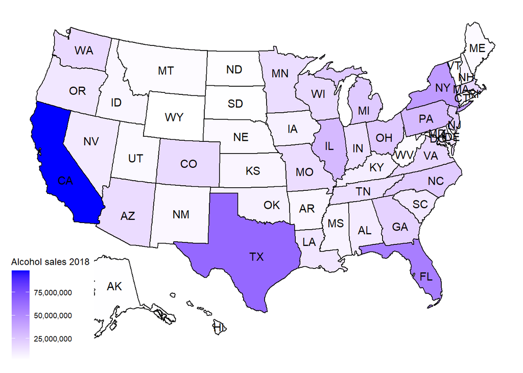

```r
ggsave('./Plots/liqour_sales_2017.png', last_plot())
### ALCOHOL sales FOR YEAR 2018 ###
plot_usmap(data = subset(map_data, year == "2018") %>% select(fips, total_gallons), values="total_gallons", labels = TRUE) +
    scale_fill_continuous(low = "white", high = "blue", name = "Alcohol sales 2018", label = scales::comma)
```

```r
ggsave('./Plots/liqour_sales_2018.png', last_plot())
```